# KD Practicum 7.1

## Classification Problems II

The goal of this exercise is to compare model performance of two classification methods applied to the same dataset. This will be the credit dataset you used in the **Practicum 6.1**.

The new method you are going to learn is the **linear discriminant analysis** (**LDA**), which is used for *classification*, *dimension reduction*, and *data visualization*. Despite its simplicity, LDA produces robust, decent, and interpretable classification results. When tackling real-world classification problems, LDA is often the benchmarking method before other more complicated and flexible ones are employed.

The key tasks of this exercise are :

- Understand how LDA works and gain the ability to interpret its output.
- Apply LDA to the credit dataset, gather performance metrics and compare them to logistic regression.
- Learn how to estimate the best cut-off for classification methods automatically by researching receiver operating characteristics, **ROC**.

### Motivation for LDA

LDA shines if there is substantial separation between the two classes because the parameter estimates for the logistic regression model become unstable. Moreover, LDA is more precise when the distribution of the predictors is approximately normal in each of the classes and the sample size is small.

**Task 1:** Think about the credit dataset. Does *balance* values fulfills all requirement for LDA? Which test would you chose to compare the distributions of balance values between defaulters and non-defaulters?

**Answer:** In **Practicum 6.1**, we have shown that there is no clear water between the two classes - the balance values of defaulters and non-defaulters overlap to a high degree. Hence, classification methods to be used will have to make compromise: either focus on properly classifying defaulters, or minimize miss-matches.

To find out whether default values of the two groups have similar distributions, you can use slew of methods ranging from graphical ones (density histograms, kernel density functions, cumulative distribution functions, boxplots, Q-Q plots, etc.) to the statistical ones (t-test, SMD, Mann-Whitney U test, permutation test, Kolmogorov-Smirnov test, etc.). There’s a good blog summing up this topic and if you are unfamiliar with it, I wholeheartedly recommend to read it. Just follow this link[^1].

Let’s quickly sum up how *balance* data look like for each group of clients. We use color-coded histograms with Kernel density functions to check how data are distributed. Panes on the right from the histogram depict the Q-Q plots that confirm our initial conclusions.

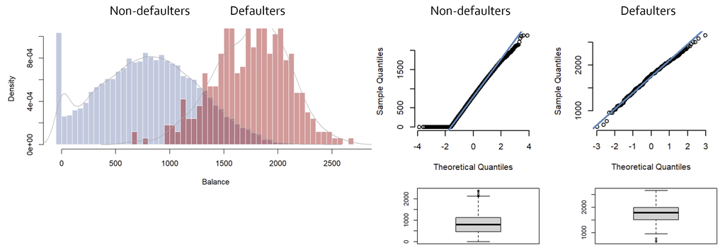

Using these plots as evidence, we state that:

- Both analyses show an enrichment of clients with 0 account balance. It is debatable, whether include them in the analysis, or omit them completely from LDA. They will impact LDA but not logistic regression because LDA uses central tendencies and standard deviation for calculations, and these are likely to be skewed by disproportionately distributed data.
- LDA is sensitive for data that are not only being normally distributed, but also expects that observations in both groups have exactly the same shape of the bell curve. In other words, they have the same variance. This is not the case for default data and this would be place to acknowledge it.

### Data preparation and hypothesis

We will use the same dataset as in **Practicum 6.1**. After data loading and preparation, the data should look like like this:

```
## # A tibble: 10,000 × 5
##      ID default student balance income
##   <int> <fct>   <fct>     <dbl>  <dbl>
## 1     1 0       0          730. 44362.
## 2     2 0       1          817. 12106.
## 3     3 0       0         1074. 31767.
## # … with 9,997 more rows
```

Same as for the logistic regression, we will use LDA to predict the default/non-default state of a client by analyzing central tendencies $\mu$ and distributions of balance $\sigma$, given prior probabilities of the two classes. Our initial hypothesis is that higher balances increase the chance of default, perhaps having more money lures one into dangerous spending habits. This assumption can be further supported by finding out that non-defaulters have on average 804 USD, whereas defaulters more than twice as much.

### Performing LDA on credit data

The proper implementation of LDA can be found in the **MASS** library, which is one of default libraries in R, although it is not loaded after R starts. To load MASS, type `library(MASS)`.

To perform a linear discriminant analysis in R, the `lda()` function is commonly used. The important arguments to this function are a *model formula* and a *data frame* containing the data. The formula is *symbolic* - as you have seen in linear and logistic regressions.

LDA is normally performed in two/three steps.

- First, you perform linear discriminant analysis by running the `lda()` function on your data. The `lda()` functions computes “discriminant scores” that helps you to classify each client into the response variable class it is in (i.e. default or not default).

  ```r
  library(MASS)
  model_lda <- lda(default ~ balance, data = data)
  model_lda
  ```

  ```
  ## Call:
  ## lda(default ~ balance, data = data)
  ##
  ## Prior probabilities of groups:
  ##      0      1
  ## 0.9667 0.0333
  ##
  ## Group means:
  ##     balance
  ## 0  803.9438
  ## 1 1747.8217
  ##
  ## Coefficients of linear discriminants:
  ##                 LD1
  ## balance 0.002206916
  ```

  You see that the readout of `lda()` summarizes prior probabilities for each class and group means (but not data dispersion $\sigma$) that are used to estimate the discriminant scores. For a single predictor (class: non-defaulter (0) vs. defaulter (1)), the LDA classifier is estimated as

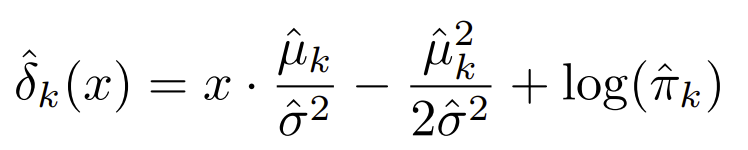

  With two classes, `lda()` calculates for each observation two $\hat{\delta_k}$ and the class is determined by $\hat{\delta_k}$ , which has higher value.
- To get values of $\hat{\delta_k}$ with the corresponding classes for each observation, a second operation is needed. You call the function `predict()`, which takes the model object generated in the first operation, extracts the reqested data and wraps them into a new object. Let’s demonstrate how it’s done.

  ```r
  lda_predict <- predict(object = model_lda)
  head(lda_predict$class) # Extract class assignment for each observation
  ```

  ```
  ## [1] 0 0 0 0 0 0
  ## Levels: 0 1
  ```

  ```r
  head(lda_predict$posterior) # Extract sigma hat values for each class
  ```

  ```
  ##           0           1
  ## 1 0.9972130 0.002786981
  ## 2 0.9958358 0.004164240
  ## 3 0.9865931 0.013406929
  ## 4 0.9988882 0.001111757
  ## 5 0.9963955 0.003604464
  ## 6 0.9933487 0.006651334
  ```

- Third, you can use the `predict()` function to find class association for data, which were not used for model training. This is similar as for logistic regression. Again, let’s see how it’s done.

  ```r
  newdata = tibble(balance=c(1000, 1300, 1700, 2000, 3000))
  lda_predict <- predict(object = model_lda, newdata = newdata)
  lda_predict$class
  ```

  ```
  ## [1] 0 0 0 0 1
  ## Levels: 0 1
  ```

  ```r
  lda_predict$posterior
  ```

  ```
  ##           0           1
  ## 1 0.9904024 0.009597568
  ## 2 0.9629403 0.037059733
  ## 3 0.8051197 0.194880326
  ## 4 0.5098647 0.490135289
  ## 5 0.0103776 0.989622399
  ```

  You can easily see that for the first four clients the probability of $\hat{\delta}_{k=0}$ is greater than $\hat{\delta}_{k=1}$. Thus, all four clients will be assigned class 0 — i.e. non-defaulters. The last client with the balance of 3000 has the value of $\hat{\delta}_{k=0}$ lower compared to the value of $\hat{\delta}_{k=1}$. Therefore, he will be classified as defaulter.

**Task 2:** Now that you have your class prediction from the linear discriminant analysis, you should compare LDA class predictions to the classes you have gathered from logistic regression with cut-off of .5 (or any you like for that matter). Your analysis should be presented as confusion matrix between the two analysis. How does logistic regression fares against LDA? Which of the two tests will better predict classes in terms of sensitivity and specificity? How many mismatches will pair-wise comparison of LDA and logistic regression will yield?

**Answer:** There are three different comparisons you need to do to fully answer **Task 2**. They are listed below and can be done easily with the R code you know.

- Compare class predictions between the ground truth and LDA.
- Compare class predictions between the ground truth and logistic regression with build-in cut-off of 0.5.
- Compare class predictions between LDA and logistic regression.

### Receiver operating characteristics

The default cut-off for logistic regression might not reflect the best cut-off there is. Hence, comparing the 0.5 cut-off to LDA does not make sense (although this is what most people do in their diploma theses). If you are to make the real comparison of two classification methods, best you chose the cut-offs that are the most optimal for each method. For most problems this will be something like the Younden index, which you won’t find by testing multiple cut-offs manually. You have to find it systematically, and that is what **receiver operating characteristics**, or **ROC**, do.

**Task 3:** In this task, you are to compare LDA classifier to the best classification cut-off that logistic regression can offer. To find the best cut-off for one or more classification methods, you need to construct the receiver operating characteristics (ROC) curve for each method and then find the point on that curve that is most top left. The method that can make it closer to the top left corner wins.

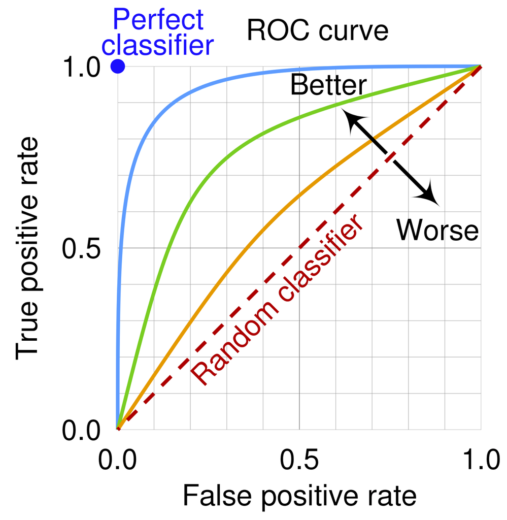

ROC curve represents the optimal trade-off between True positive rate (**TPR**) and False positive rate (**FPR**). That is, the best trade of between identifying as many true defaulters whilst miss-classifying as few non-defaulters. It is plotted as a curve that comes from an iterative calculation of TPR and FPR, starting from a single defaulter with the highest balance, then adding the defaulter with the second highest balance to the set (containing just the first defaulters at this point) and so on.

Your task is to:

- Research how to perform ROC analysis on your logistic regression classifier you have done last week on credit dataset.
- There are plethora libraries that implement several solutions and you are welcome to try pROC, ROCR and ROCit. Do all these solutions offer the same level of information? Same degree of detail in visualizations?
- Compare the best cut-off of logistic classifier represented either by Youden index or “top-left” point to LDA. Which method wins? Is there another way how to do this automatically without manual comparison of cut-offs?
- (**optional**) To what balance values and their respective probabilities translates the best cut-off from logical regression and LDA?

If you want to take this task as a challenge, or a self-learning exercise, do not read further.

### ROCit : best for model comparison

Let’s start with **ROCit**, which is a good package for ROC plotting and offers some interesting data along the way. You can install the package with `install.packages("ROCit")`. The ROC creation will be carried out in a single step, assuming that you have logistic regression model available as an object. If not, let’s start from the beginning.

- Create a logistic regression model using credit dataset.

  ```r
  model_glm <- glm(default ~ balance, data = data, family = binomial)
  ```

- To see the ROC curve you can use the `rocit()` function, which creates the ROC object that can be passed to the `plot()` function.

  ```r
  library(ROCit)
  roc <- rocit(class = model_glm$y,
               score = model_glm$fitted.values)
  ```

[figure not shown]

- This is however not very informative. You want to see more. Especially, if you are to compare two models you need a new measure that is called **area under ROC**, or **AUC** for starters. This information becomes available after typing:

  ```r
  summary(roc)
  ```

  ```
  ##
  ##  Method used: empirical
  ##  Number of positive(s): 333
  ##  Number of negative(s): 9667
  ##  Area under curve: 0.948
  ```

  **The higher number is the better.** AUC provides an aggregate measure of performance across all possible classification thresholds. One way of interpreting AUC is as the probability that the model ranks a random positive example more highly than a random negative example. It is also important to remember that
  - AUC is **scale-invariant**. It measures how well predictions are ranked, rather than their absolute values.
  - AUC is **classification-threshold-invariant**. It measures the quality of the model’s predictions irrespective of what classification threshold is chosen.
- Now, repeat these steps for LDA and see which of the two classification methods is better. LDA classification are available as factors from `lda_predict$class`, whilst the ground truth is located in `data$default`. Which method wins?

### pROC: best for data mining

  ```r
  library(pROC)
  pROC <- roc(data$default, data$balance, algorithm = 2)
  ```

- It is not particularly graphically appealing even if you plot the object. However, the wealth data are good when you want to dig in. For example, **which balance values corresponds the best cut-off you can get from logistic regression**? For those questions, we can use other functions packed within pROC.

  ```r
  pROC_results <- coords(pROC, "local maximas", ret=c("threshold", "sens", "spec",
                                            "ppv", "npv", "youden", "closest.topleft"))
  head(pROC_results)
  ```

  ```
  ##   threshold sensitivity specificity        ppv       npv   youden
  ## 1  652.3849    1.000000   0.3807800 0.05269821 1.0000000 1.380780
  ## 2  698.5398    0.996997   0.4153305 0.05548128 0.9997510 1.412328
  ## 3  779.9149    0.993994   0.4818455 0.06198502 0.9995708 1.475839
  ## 4  959.1111    0.990991   0.6266680 0.08377761 0.9995050 1.617659
  ## 5  961.4805    0.987988   0.6284266 0.08390717 0.9993420 1.616415
  ## 6  961.6541    0.984985   0.6285301 0.08369482 0.9991778 1.613515
  ##   closest.topleft
  ## 1       0.3834334
  ## 2       0.3418474
  ## 3       0.2685202
  ## 4       0.1394579
  ## 5       0.1382111
  ## 6       0.1382154
  ```

  ```r
  tail(pROC_results)
  ```

  ```
  ##     threshold sensitivity specificity       ppv       npv   youden
  ## 214  2134.475  0.11411411   0.9993793 0.8636364 0.9703696 1.113493
  ## 215  2152.313  0.10210210   0.9994828 0.8717949 0.9699829 1.101585
  ## 216  2218.648  0.06606607   0.9995862 0.8461538 0.9688189 1.065652
  ## 217  2315.388  0.03903904   0.9996897 0.8125000 0.9679487 1.038729
  ## 218  2378.889  0.02402402   0.9997931 0.8000000 0.9674675 1.023817
  ## 219  2402.164  0.02102102   1.0000000 1.0000000 0.9673772 1.021021
  ##     closest.topleft
  ## 214       0.7847942
  ## 215       0.8062209
  ## 216       0.8722328
  ## 217       0.9234461
  ## 218       0.9525291
  ## 219       0.9583998
  ```

### References

[^1]: https://towardsdatascience.com/how-to-compare-two-or-more-distributions-9b06ee4d30bf